# The impact of isosmotic conditions on the metabolism and hypoxia tolerance of a reportedly oxyconforming teleost

Timothy D. Clark, Luis L. Kuchenmüller, Elizabeth C. Hoots, Maryane Gradito, Jake M. Martin

17 February 2026

[figure not shown]

# 📕 READ ME

**SUMMARY** This R code estimates the relationship between oxygen consumption (MO₂) and dissolved oxygen saturation (DO) in the Common Galaxias (*Galaxias maculatus*). It also estimates the critical oxygen saturation value for aerobic metabolism O<sub>2crit</sub>, commonly defined as the threshold below which the oxygen consumption rate can no longer be sustained. The associated article is titled *“The role of osmorespiratory compromise in metabolism and hypoxia tolerance of a purportedly oxyconforming teleost.”* If you are reading the HTML version of this script, click the `Code` button in the top right to download the `.Rmd` file.

**AIM** The article aims to test whether *Galaxias maculatus* can maintain oxygen consumption (MO₂) as ambient DO declines and, if so, at what level it reaches the critical oxygen saturation value for aerobic metabolism (O<sub>2crit</sub>).

**AUTHORS** Timothy D. Clark <sup>[a]</sup> Luis L. Kuchenmüller <sup>[a]</sup> Elizabeth C. Hoots <sup>[a]</sup> Maryane Gradito <sup>[a]</sup> Jake M. Martin <sup>[a,b]</sup>

**AFFILIATIONS** [a] School of Life and Environmental Sciences, Deakin University, Geelong, VIC, Australia  
[b] Department of Wildlife, Fish and Environmental Studies, Swedish University of Agricultural Sciences, Umeå, Sweden

**DISCLAIMER** I (Jake Martin) am dyslexic. I have made an effort to review the script for grammatical errors, but some will likely remain. I apologise. Please feel free to reach out using the contact details below if anything is unclear.

# 📧 Contact

**Jake M. Martin**

📧 **Email:** jake.martin@deakin.edu.au

📧 **Alt Email:** jake.martin.research@gmail.com

🌐 **Web:** [jakemartin.org](https://jakemartin.org/)

🐙 **GitHub**: JakeMartinResearch

# 📑 Sharing/accessing and citing

1. **Licenses/restrictions placed on the data:** CC-BY 4.0
2. **Link to the associated publication:**  
   🚧 *To be added* 🚧
3. **Recommended citation for this data:**

Clark, T. D., Kuchenmüller, L. L., Hoots, E. C., Gradito, M., & Martin, J. M. (2025, May 28). The impact of isosmotic conditions on the metabolism and hypoxia tolerance of a reportedly oxyconforming teleost. https://doi.org/10.17605/OSF.IO/GFXCA

# 🔧 Set up: Packages and knit settings

A list of the required packages to run the script.

```r
# ----- Packages ------
if (!requireNamespace("pacman", quietly = TRUE)) install.packages("pacman")

# ---- List of required packages ----
pkgs <- c(
  # ----- Data Visualisation -----
  "ggthemes", "bayesplot", "gt", "gtsummary", "plotly", "qqplotr", "gridExtra", "flextable",

  # ----- Tidy Data and Wrangling -----
  "tidyverse", "janitor", "readxl", "broom.mixed", "data.table", "hms", "devtools",
  "mclust", "officer", "here",

  # ----- Modelling and Statistical Analysis -----
  "brms", "rstan", "marginaleffects", "performance", "emmeans",
  "tidybayes", "respirometry", "future"
)

# ---- Install and load all packages using pacman ----
suppressPackageStartupMessages(
  pacman::p_load(char = pkgs, install = TRUE)
)

#-------kniter seetting-----------

knitr::opts_chunk$set(
  echo = FALSE, # only for PDF knit
  message = FALSE,
  warning = FALSE, # no warnings
  cache = TRUE,# cacheing to save time when kniting
  tidy = TRUE,
  fig.align = "center"
)
```

# 📦 Custom functions

Here are some custom functions used within this script.

`bayes_incremental_regression_by_id()`: A custom function to build Bayesian incremental regressions. It is designed to run a list of subgroup models (IDs) in parallel using 4 cores. The function uses `brm()` with a Gaussian error distribution.

**Use**:  
The function accepts the following arguments:  
- `id_i`: A grouping factor or ID used to filter the data for each regression. If none is provided, the function uses the entire dataset.  
- `id_name`: The column name (as a character string) corresponding to the grouping factor in the data frame. If not provided, the function uses all data.  
- `data`: The data frame containing the variables for analysis.  
- `predictor`: The predictor variable of interest.  
- `response`: The response variable of interest.  
- `seed_number`: A random seed value for model reproducibility.  
- `save_models`: A logical argument indicating whether to save the model outputs (`TRUE` or `FALSE`).  
- `mod_output_wd`: The output directory where model `.rds` files should be saved (used only if `save_models = TRUE`).

`load_rds9()`: A custom function to load all rds models in a directory and store in a list. Takes a directory with `.rds` files

`incremental_regression_bayes_fits()`: A custom function for pulling model fits, loo and r2 using `loo()` and `bayes_R2()`, respectively. Takes a list of `brm` models.

`bayes_mod_predictions()`: This function extracts the predicted values using `fitted()` from a list of models and combines them with the original data file used for the model. These are the **posterior mean fitted values** (i.e. the expected value of the response variable given the predictor variables and the estimated posterior distributions of the parameters) for each observation in the dataset, along with **95% credible intervals**.

`calcSMR()`: **authored by Denis Chabot** used to estimate SMR with several different methods Claireaux and Chabot (2016) <sup>[1]</sup>

<sup>[1]</sup> Claireaux, G. and Chabot, D. (2016) Responses by fishes to environmental hypoxia: integration through Fry’s concept of aerobic metabolic scope. Journal of Fish Biology https://doi.org/10.1111/jfb.12833

`calcO2crit()`: **authored by Denis Chabot** used to estimate O2crit (Pcript). Claireaux and Chabot (2016) <sup>[1]</sup>

*Note: O2 is assumed to be in percentage of dissolved oxygen (DO)*

`plotO2crit()`: **authored by Denis Chabot**, used to plot the modes used for the `calcO2crit()` function. Claireaux and Chabot (2016) <sup>[1]</sup>

*Note: I added abline(h=lowestMO2, col=“pink”) so that I could visualise the lowestMO2 position*

# 📂 Directories

## Input

**📥 input_data_wd**: Directory for the metadata

**📥 mod_data_wd**: Directory for model output data estimated slopes

## Output

**📤 output_fig_wd**: this is where we will put the figures

**📤 output_mods_wd**: this is where we will put the models

# 💿 Data

## Slopes (ṀO)

**💿 slope_df**: We have imported the slopes extracted in LabChart during each phase of the experiment

## Fish metadata

**💿 metadata**: This is the meta data for each chamber

*Note: We are also adding volume based on chamber type.*

## Urbina, Glover, and Forster (2012)

**💿 urbina_et_al_2012**: This is the mean level data extracted from Urbina, Glover, and Forster (2012)<sup>[2]</sup> Figure 1a. We used the metaDigitise package in R to extract the data <sup>[3]</sup>.

## O₂crit viusal inspection

**💿 o2crit_check**: This data frame includes the visual based assessment for O₂crit for all fish included in the analysis (*n* = 58). The inspections were made using figures genbrated by the `plotO2crit()` function, and can be viewed in `combined_chabot_plots.pdf`. The visual assessment was done independently by all authors, and the presence of an O₂crits allocated to ‘yes’, ‘no’, ‘maybe’. If yes, or maybe, an estimate of the dissolved oxygen percentage was given.

Directory to the figures

📁 gmac-mo2-24/ └── 📂 output-fig/  
└── 📂 model_chabot/ └── 📄 combined_chabot_plots.pdf

### Combinding metadata

Adding the meta data to the slopes data frame

# 🧹 Data tidy

## Numbers

We have **64 fish** with MO₂ data

```
## [1] "n = 64"
```

| Salinity group | n total |
| --- | --- |
| 0 | 33 |
| 9 | 31 |

## Fish size

Here we calculate the mean length and size of fish used in the experiment.

```
## [1] "The mean mass of fish was 0.532 g (range: 0.21-1.6), and the mean length was 50.41 mm (range: 40-70)"
```

## Filtering trials

We will remove 6 trials which had errors. These are as follows:

- a_0_25nov_3 fish died during trial
- b_0_26nov_4 flat lined early
- c_0_22nov_2 chamber was opened early
- c_9_26nov_2 chamber was opened early
- c_9_26nov_4 chamber was opened early
- d_9_27nov_3 sensor was jumpy and end points were hard to confidently ID visually

We now have **58 fish** with MO2 data

```
## [1] "n = 58"
```

With 30 in the 0 ppt group and 28 in the 9 ppt group

| Salinity group | n total |
| --- | --- |
| 0 | 30 |
| 9 | 28 |

Mass and size of fish after removing 6 trials which had errors

```
## [1] "The mean mass of fish was 0.546 g (range: 0.21-1.6), and the mean length was 50.9 mm (range: 40-70)"
```

Chamber size breakdown

| Chamber type | n total | Median mass | Standard deviation mass |
| --- | --- | --- | --- |
| 0.058 | 36 | 0.43 | 0.1496554 |
| 0.105 | 21 | 0.61 | 0.2561871 |
| 0.300 | 1 | 1.60 | 0.0000000 |

Numbers per trial approach

| Type of trial | n total |
| --- | --- |
| 100c | 19 |
| 50c | 39 |

## Filtering MO₂ estimates

Here we apply the following filters to the MO₂ data:

- Remove the first 5 SMR cycles (burn in)
- Remove all positive raw slopes
- Remove all MO₂ calculated using less then 60 data points (5 min at 0.2 Hz)
- Remove all MO₂ calculated if O₂ increases in a closed phase (i.e. trial has ended)

Check positive values for MO₂ before removing.

```
## [1] "There are 13 fish with postive slopes. These fish are: a_0_24nov_1, b_0_24nov_3, b_9_21nov_2, b_9_21nov_3, b_9_22nov_1, b_9_22nov_2, b_9_22nov_3, c_0_21nov_1, c_0_21nov_2, c_0_22nov_4, c_9_24nov_3, d_0_22nov_2, d_9_25nov_3. For all estimated slopes (n = 1105) 1.27% were postive (n = 14)"
```

Filtering the MO₂ data

## Calculating SMR

We will calculate SMR using `calcSMR` function by Chabot, Steffensen and Farrell (2016)<sup>[1]</sup>. Specifically, we use mean of the lowest normal distribution (MLND) where CVmlnd < 5.4 and the mean of the lower 20% quantile (q0.2) were CVmlnd > 5.4. If CVmlnd is not calculated we have used q0.2.

## Transforming MO₂

Here we are transforming the MO₂ units. The resulting values are as follows:

- **MO2** is absolute value of the background and leak corrected MO₂ slope from Labchart (mo2corr) times the net volume of the chamber (volume - fish mass), × 60, × 60, to achieve MO₂ as mg<sup>-1</sup> O₂ h<sup>-1</sup>
- **MO2_g** is MO2 divided by fish mass to achieve MO₂ as mg<sup>-1</sup> O₂ g<sup>-1</sup> h<sup>-1</sup> (i.e. mass standardised)
- **SMR** absolute value of the SMR estimates using methods described by Chabot, Steffensen and Farrell (2016)<sup>[1]</sup> times the net volume of the chamber (volume - fish mass), × 60, × 60, to achieve SMR as mg<sup>-1</sup> O₂ h<sup>-1</sup>)
- **SMR_g** is SMR divided by fish mass to achieve SMR as mg<sup>-1</sup> O₂ g<sup>-1</sup> h<sup>-1</sup> (i.e. mass standardised)
- **DO** is dissolved oxygen percentage calculated from O₂ values (mg<sup>-1</sup> L<sup>-1</sup>) using the recorded temperature, salinity, and a constant atmospheric pressure (Pa; 1013.25)
- **o2_kpa** is the O₂ concentration in kilopascal (kpa). This is used to make a comparative figure only.

Trial lengths

| Approach | Minimum duration | Maximum duration | Median duration |
| --- | --- | --- | --- |
| Closed at 100% air saturation | 3 | 13 | 7 |
| Closed at 75% and 50% air saturation | 2.91 | 8.02 | 5.96 |

## Visualising MO2 corrections

Let’s check how data corrections change the appearance of out data MO2

Let’s compare raw MO2 calculations (mo2), MO2 calculations after correcting background respiration (mo2_bground), and MO2 calculations after correcting for background respiration and oxygen diffusion dynamics (mo2corr). First we will need to make the mo2_bground vaule as it’s not present in the datafile, and transform the data to long formate, so we can plot it more easly.

### Figure S1

Now let’s plot them in the same graph for each fish: raw MO₂ calculations are shown in pink, MO₂ calculations after correcting for background respiration are shown in grey, and MO₂ calculations after correcting for background respiration and oxygen diffusion dynamics are shown in green.

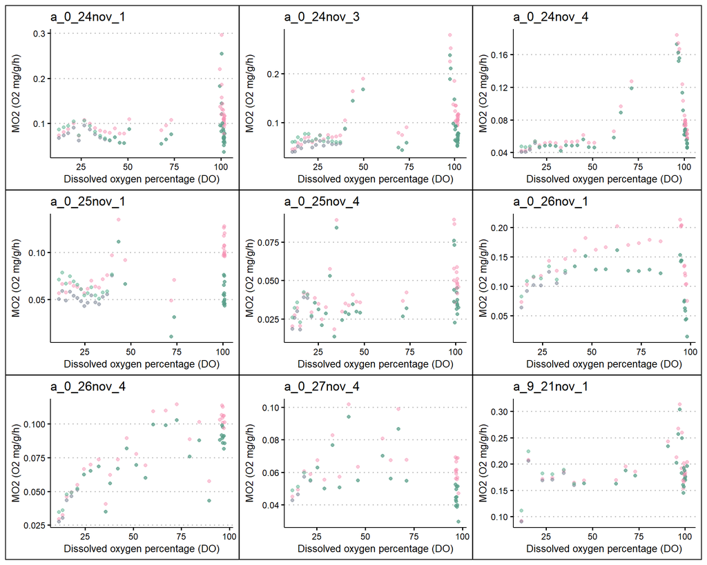

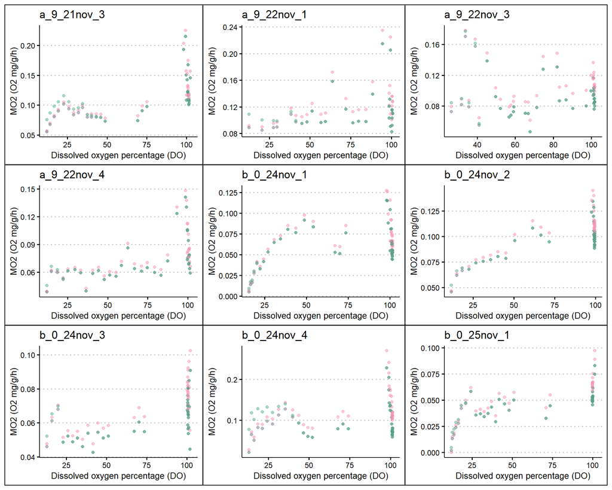

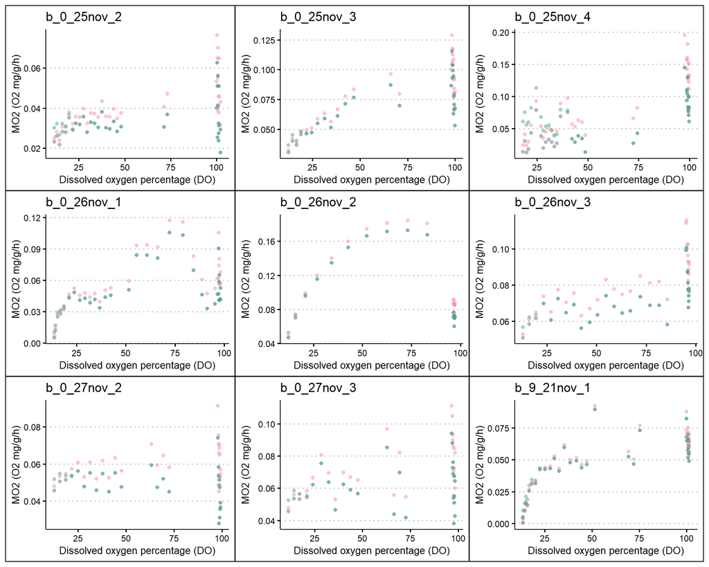

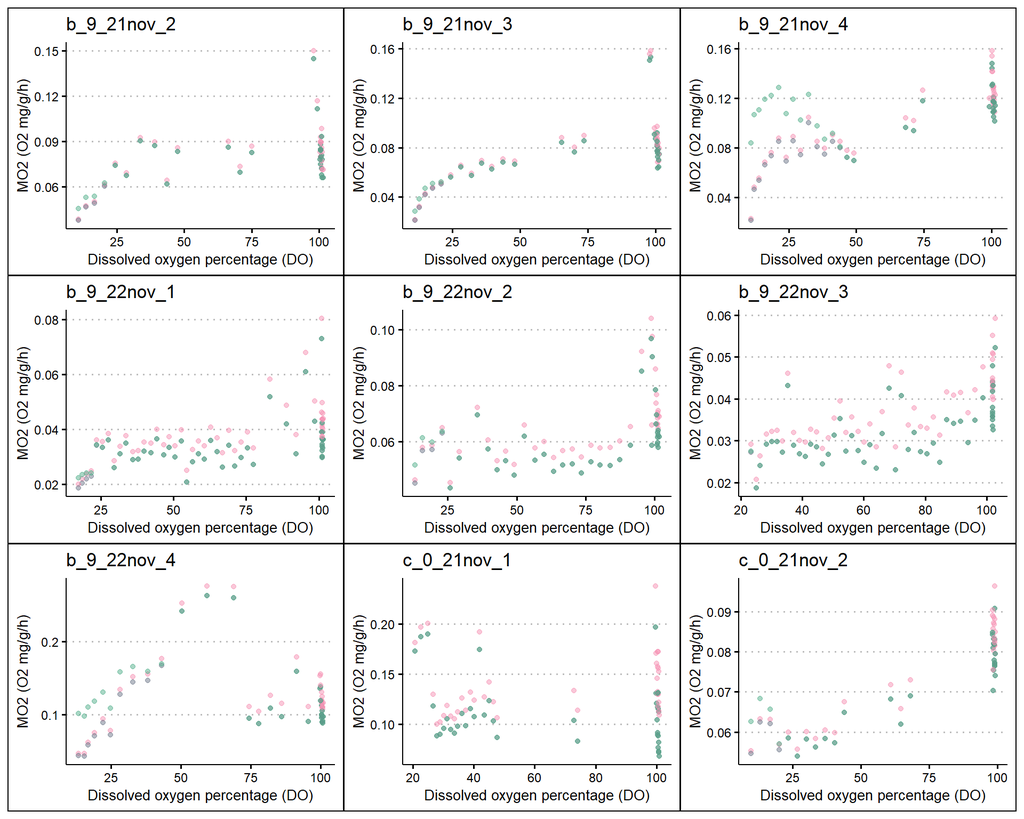

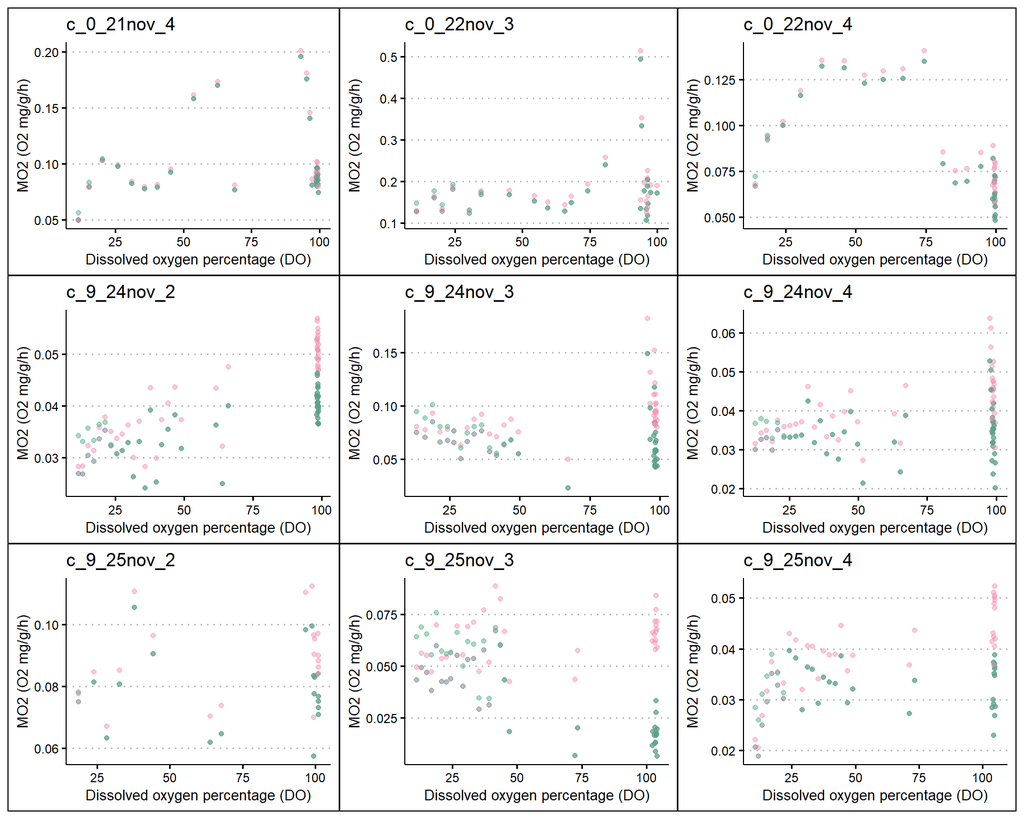

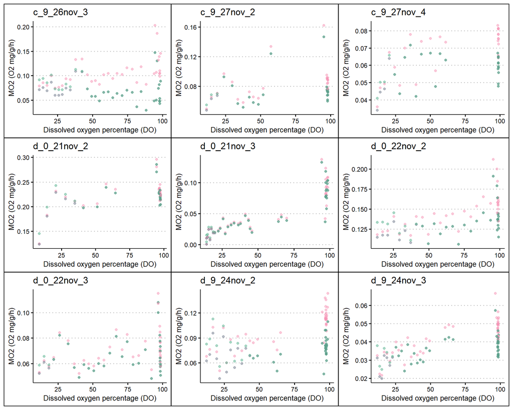

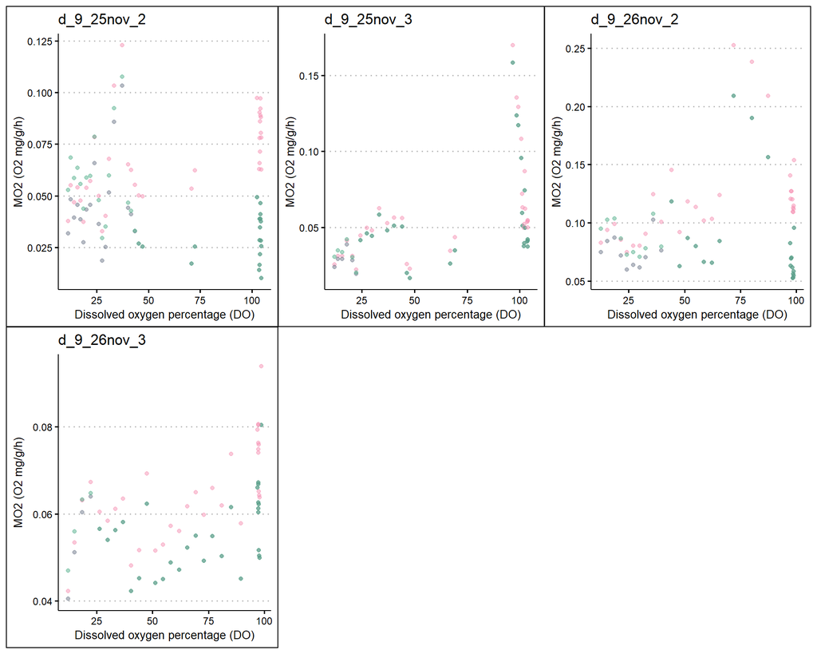

**Figure S1**: Individual fish-level plots showing the relationship between dissolved oxygen (DO) percentage and metabolic oxygen consumption rate (MO₂, in mg O₂/g/h) for each 20-min interval. Each panel displays data for a single fish (fish ID in the top left of the plot). Points are colour-coded by the type of MO₂ calculation: raw MO₂ (pink, #f692B4), background-corrected MO₂ (grey, #6E7889), and fully corrected MO₂ (accounting for background respiration and oxygen diffusion dynamics) (green, #53af8b). Each point represents a measurement at a specific DO level, and the slight transparency (alpha = 0.5) highlights overlapping observations.

# 📊 Exploratory Data Analysis (EDA)

## O₂ vs MO₂

### Figure S2

This interactive was used to identify any outliers, or potential errors. This has not been generated in the PDF `Supplementary file 1`, as it is not compatible.

*Figure S2:* interactive plot of metabolic rate measurements (MO₂; mg O₂ g<sup>-1</sup>h<sup>-1</sup>) by dissolved oxygen percentage (DO) for all fish, including all estimates during the SMR phase (i.e. intermittent phase). Individual linear regression were fitted for visual reference, and do not represent the best fitting regression.

### Figure S3

Looking at the difference responses in the two salinity groups.

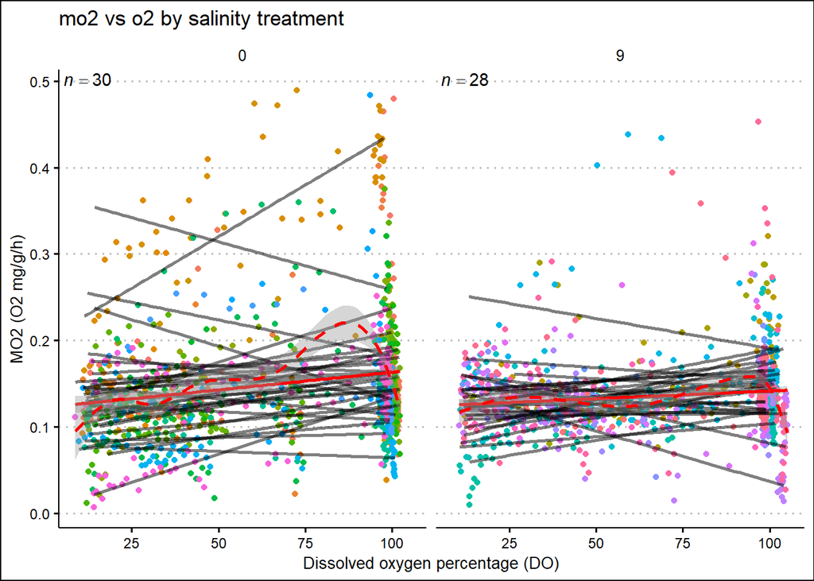

*Figure S3:* Metabolic rate measurements (MO₂; mg O₂ g<sup>-1</sup>h<sup>-1</sup>) by dissolved oxygen percentage (DO) for fish from the two salinity treatments, including all estimates during the SMR phase (i.e. intermittent phase). Individual linear regression were fitted for visual reference, and do not represent the best fitting regression. The solid red and dashed red line represents the global trend in each of the treatments, both a linear (solid red) and non-linear (dashed red; Generalized Additive Model fitted with `geom_smooth`).

### Figure S4

A plot to look at the different chamber types

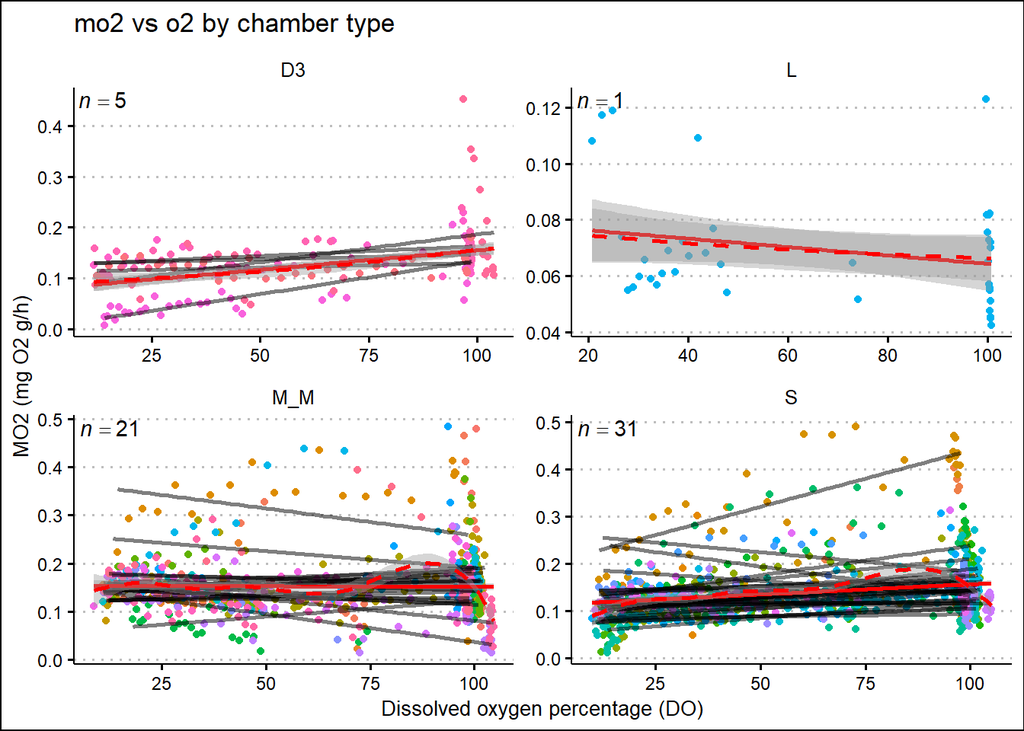

*Figure S4:* Metabolic rate measurements (MO₂; mg O₂ g<sup>-1</sup>h<sup>-1</sup>) by dissolved oxygen percentage (DO) for fish tested in the 4 different chamber types, including all estimates during the SMR phase (i.e. intermittent phase). Individual linear regression were fitted for visual reference, and do not represent the best fitting regression. The solid red and dashed red line represents the global trend in each of the treatments, both a linear (solid red) and non-linear (dashed red; Generalized Additive Model fitted with `geom_smooth`).

## Routine MO₂

Making an SMR phase only data frame

Routine MO<sub>2</sub> by salinity. Plot of all MO<sub>2</sub> measures during SMR phase by salinity treatment. The small points are the raw observed values, the shaded area behind the points is the a kernel density of the observed data, the box plot shows the median and interquartile range (IQR), and the large point shows the mean.

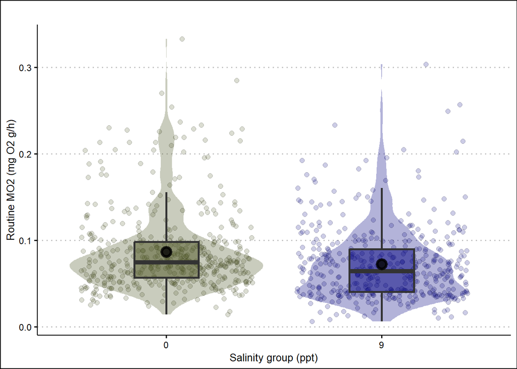

## SMR

Here’s the same plot but for only the SMR, as estimated with calcSMR function by Chabot, Steffensen and Farrell (2016)<sup>[1]</sup>. Specifically, we use mean of the lowest normal distribution (MLND) where CVmlnd < 5.4 and the mean of the lower 20% quantile (q0.2) were CVmlnd > 5.4. If CVmlnd is not calculated we have used q0.2.

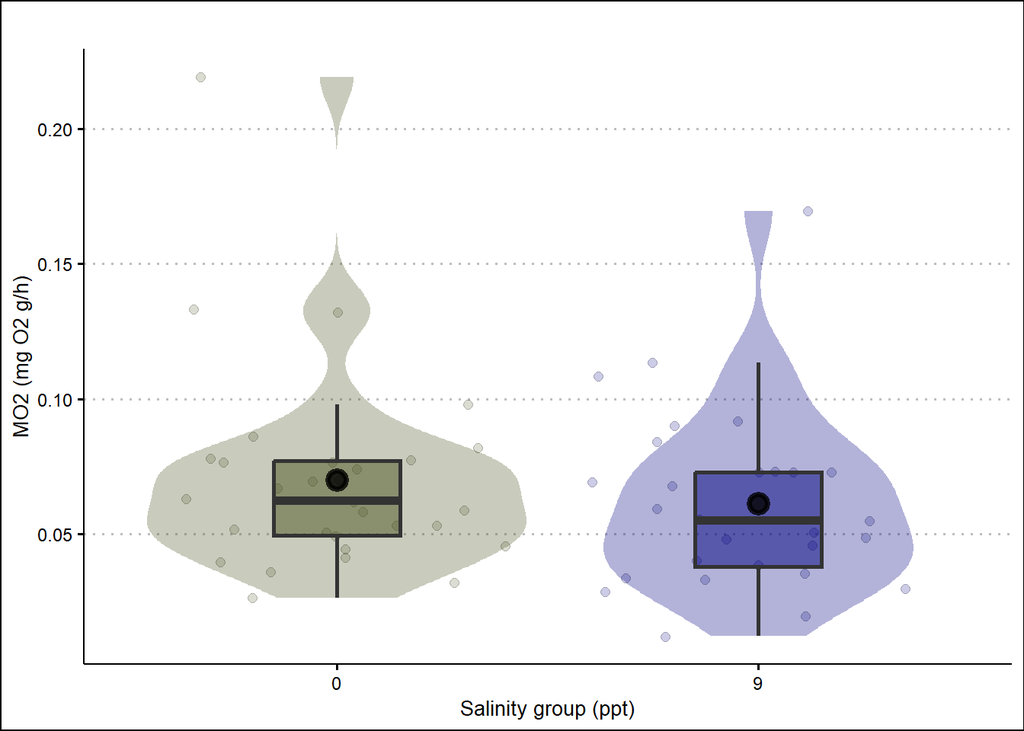

## Individual O₂, MO₂, and SMR

Here we will plot the individual relationship between O₂, MO₂, and SMR for all fish

Create output directory if needed

Loop through each fish ID to create a plot, save these to a single PDF file, this is called `combined_slopes.pdf`. It can be found in this path `output-fig/slopes/combined_slopes.pdf` These plots show Metabolic rate measurements (MO₂; mg O₂ g<sup>-1</sup>h<sup>-1</sup> by O<sub>2</sub>) at each of the four experimental phase (the over night SMR intermittent-flow respirometry phase, closed phases at 50%, 75% or 100% O<sub>2</sub>). The estimated SMR value is represented as a dashed red line.

# 🧮 Analysis

## Routine MO2

### Scaling predictors

Here we scale our predictors for the model. We have first applied an log transformation to mass, so its directly interpretable as the mass-scaling exponent, just like in metabolic theory.

Summary of predictors used in the model below

| temp_range | mass_range | cycle_range | number_fish |
| --- | --- | --- | --- |
| 13.84–14.38 | 0.21–1.6 | 5–27 | 58 |

### Model structure

Here we will use a Bayesian Generalised Linear Mixed Model (GLMM) with a Gamma distribution and a log link, where the shape parameter (α) is also modelled as a function of predictors. This models MO<sub>2</sub> by salinity during the SMR phase to see if the fish held at different salinities have different RMRs. We have also added a few scaled predictors, that may help describe variation in the data, such as mass (g; 0.21–1.6) temperature (°C; 13.84–14.38), cycle order (5–27), and light/dark cycle (light or dark; light between 07:00:00 and 19:00:00), we also include a random effect for fish id to account for multiple MO<sub>2</sub> measures on each fish (1–58). We allowed the the shape parameter (α) to vary as a function of some of the predictors (e.g. salinity_group, order_z) to improve fit.

### Prior selection

These are the default priors. We will use these.

| prior | class | coef | group | resp | dpar | nlpar | lb | ub | source |
| --- | --- | --- | --- | --- | --- | --- | --- | --- | --- |
|  | b |  |  |  |  |  |  |  | default |
|  | b | light_dark_c |  |  |  |  |  |  | default |
|  | b | log_mass_c |  |  |  |  |  |  | default |
|  | b | order_c |  |  |  |  |  |  | default |
|  | b | salinity_group9 |  |  |  |  |  |  | default |
|  | b | temp_c |  |  |  |  |  |  | default |
| student_t(3, -2.7, 2.5) | Intercept |  |  |  |  |  |  |  | default |
| student_t(3, 0, 2.5) | sd |  |  |  |  |  | 0 |  | default |
|  | sd |  | id |  |  |  |  |  | default |
|  | sd | Intercept | id |  |  |  |  |  | default |
|  | b |  |  |  | shape |  |  |  | default |
|  | b | order_c |  |  | shape |  |  |  | default |
|  | b | salinity_group9 |  |  | shape |  |  |  | default |
| student_t(3, 0, 2.5) | Intercept |  |  |  | shape |  |  |  | default |

### Run model

Here we run the model, I have hashed this out because I have saved the model for quick reloading.

⏭️ **Skip this step** if you have downloaded the saved model `mo2_mod_gamma.rds` from GitHub (or pulled the entire GitHub project)

Here we reload the model

### Model diagnostics

Checking model convergence

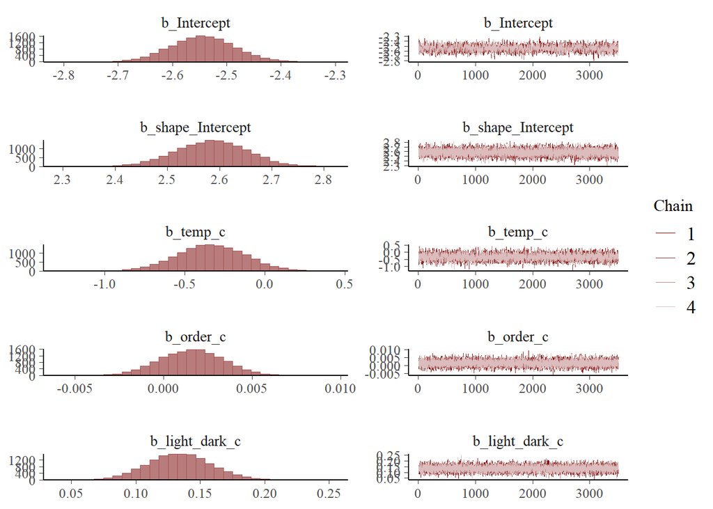

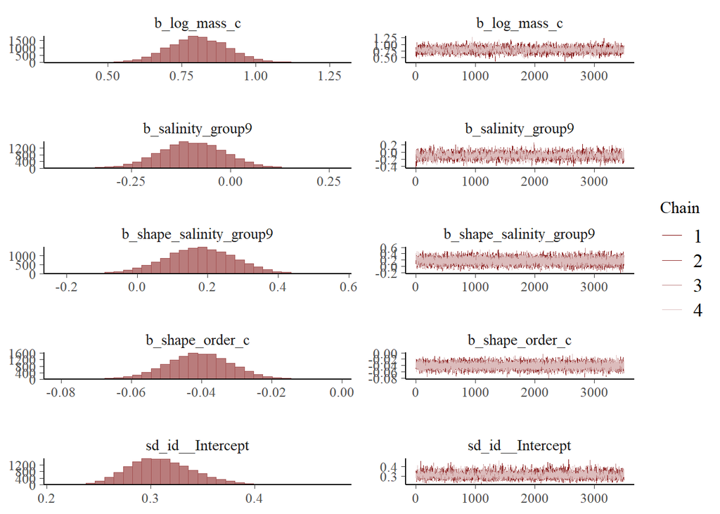

Checking rhat are equal to one

```
##  Family: gamma
##   Links: mu = log; shape = log
## Formula: MO2 ~ temp_c + order_c + light_dark_c + log_mass_c + salinity_group + (1 | id)
##          shape ~ salinity_group + order_c
##    Data: slope_tidy_smr (Number of observations: 893)
##   Draws: 4 chains, each with iter = 8000; warmup = 1000; thin = 2;
##          total post-warmup draws = 14000
##
## Multilevel Hyperparameters:
## ~id (Number of levels: 58)
##               Estimate Est.Error l-95% CI u-95% CI Rhat Bulk_ESS Tail_ESS
## sd(Intercept)     0.31      0.03     0.26     0.38 1.00     4013     6644
##
## Regression Coefficients:
##                       Estimate Est.Error l-95% CI u-95% CI Rhat Bulk_ESS
## Intercept                -2.54      0.06    -2.66    -2.43 1.00     2241
## shape_Intercept           2.58      0.07     2.45     2.72 1.00    12143
## temp_c                   -0.33      0.21    -0.75     0.09 1.00     6431
## order_c                   0.00      0.00    -0.00     0.01 1.00    11445
## light_dark_c              0.13      0.02     0.09     0.18 1.00    12311
## log_mass_c                0.81      0.10     0.61     1.01 1.00     2943
## salinity_group9          -0.10      0.08    -0.26     0.07 1.00     2304
## shape_salinity_group9     0.18      0.10    -0.03     0.37 1.00    12404
## shape_order_c            -0.04      0.01    -0.06    -0.02 1.00    11624
##                       Tail_ESS
## Intercept                 4183
## shape_Intercept          12331
## temp_c                    9409
## order_c                  12155
## light_dark_c             12266
## log_mass_c                5032
## salinity_group9           4394
## shape_salinity_group9    12389
## shape_order_c            12394
##
## Draws were sampled using sampling(NUTS). For each parameter, Bulk_ESS
## and Tail_ESS are effective sample size measures, and Rhat is the potential
## scale reduction factor on split chains (at convergence, Rhat = 1).
```

Using leave one out (loo) measure of fit, the model appears to preform well, all, but one Pareto k estimates are good (k < 0.7)

```
##
## Computed from 14000 by 893 log-likelihood matrix.
##
##          Estimate   SE
## elpd_loo   2256.8 38.9
## p_loo        71.6  7.1
## looic     -4513.5 77.8
## ------
## MCSE of elpd_loo is NA.
## MCSE and ESS estimates assume MCMC draws (r_eff in [0.7, 1.0]).
##
## Pareto k diagnostic values:
##                          Count Pct.    Min. ESS
## (-Inf, 0.7]   (good)     892   99.9%   765
##    (0.7, 1]   (bad)        1    0.1%   <NA>
##    (1, Inf)   (very bad)   0    0.0%   <NA>
## See help('pareto-k-diagnostic') for details.
```

Model predictions generally align with the observed data

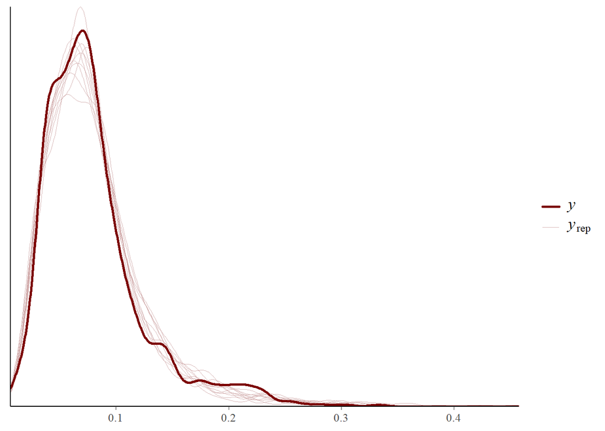

### 📈 Results

We did not see a meaningful difference between the routine metabolic rate for fish from the two salinity treatments.

#### Table S1

**Table S1**: Fixed effect Estimates (β) and 95% Credible Intervals (95% CI)

| Predictor | β | 95% CI |
| --- | --- | --- |
| Intercept | -2.545 | [-2.659, -2.428] |
| shape_Intercept | 2.585 | [2.45, 2.715] |
| temp_c | -0.335 | [-0.755, 0.087] |
| order_c | 0.002 | [-0.002, 0.005] |
| light_dark_c | 0.134 | [0.086, 0.182] |
| log_mass_c | 0.805 | [0.609, 1.006] |
| salinity_group9 | -0.096 | [-0.259, 0.066] |
| shape_salinity_group9 | 0.177 | [-0.025, 0.372] |
| shape_order_c | -0.041 | [-0.059, -0.023] |

Looking at the marginal mean MO2 for each salinity treatment

| salinity_group | emmean | lower.HPD | upper.HPD |
| --- | --- | --- | --- |
| 0 | 0.079 | 0.070 | 0.088 |
| 9 | 0.071 | 0.064 | 0.080 |

| contrast | estimate | lower.HPD | upper.HPD |
| --- | --- | --- | --- |
| salinity_group0 - salinity_group9 | 1.1 | 0.94 | 1.29 |

EEM contrasts for the two light phases, where -0.5 is dark, and 0.5 is light

| contrast | estimate | lower.HPD | upper.HPD |
| --- | --- | --- | --- |
| light_dark_c0.5 - (light_dark_c-0.5) | 1.14 | 1.09 | 1.2 |

Here we we calculate the model-estimated marginal means for MO2 for a unit increase in mass and transform this onto a fold-change scale. Where log(mass) has be centered, a vaule of 0 represents the mean mass of fish, and 1 corresponds to a fish with log(mass) = 1 unit above the mean (i.e. 2.7 times large).

log(mass<sub>2</sub>) = log(mass<sub>1</sub>)+1

If you exponentiate both sides:

mass<sub>2</sub> = mass<sub>1</sub> x exp(1)

mass<sub>2</sub> ≈ mass<sub>1</sub> x 2.718

| contrast | estimate | lower.HPD | upper.HPD |
| --- | --- | --- | --- |
| log_mass_c1 - log_mass_c0 | 2.23 | 1.86 | 2.76 |

Pulling the emmeans draws for our plot

#### Figure 1a

*NOTE: This plot is in the main text of the manuscript, which is way it is called Figure 1a (not Figure Si)*

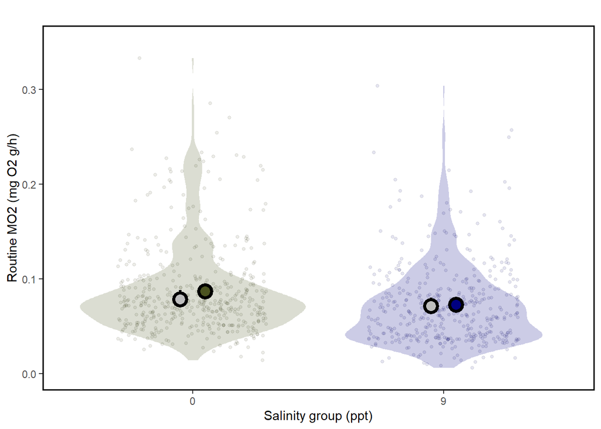

**Figure 1a:** Routine metabolic rate (i.e. MO<sub>2</sub> (mg<sup>-1</sup> O<sub>2</sub> h<sup>-1</sup>) measured during SMR meassurments) plotted by salinity treatment. The small transparent points are the observed values, the shaded area behind the points is the a kernel density of the observed data, the large coloured point (to the right) is the observed mean, the large grey point with error bars (to the left) is the model estimated marginal mean (eemean) 95% Credible Intervals (95% CI).

There was moderate but meaningful variation in RMR between individuals, even after accounting for mass, temperature, salinity, and light phase. The estimated standard deviation of individual RMR was 0.31 [0.26 to 0.38], indicating that individual identity explained a meaningful proportion of the observed variation.

| Estimate | Est.Error | l-95% CI | u-95% CI | Rhat | Bulk_ESS | Tail_ESS |
| --- | --- | --- | --- | --- | --- | --- |
| 0.3109591 | 0.0317821 | 0.2555882 | 0.3785216 | 1.000639 | 4013.05 | 6644.265 |

## SMR

### Formating and scaling data

Here we are filtering the data frame to have only measure per fish for the SMR estimate

Summary of predictors used in the model below

| temp_range | mass_range | cycle_range | number_fish |
| --- | --- | --- | --- |
| 13.87–14.26 | 0.21–1.6 | 10–23 | 58 |

### Prior selection

These are the default priors for the model. We will use these.

| prior | class | coef | group | resp | dpar | nlpar | lb | ub | source |
| --- | --- | --- | --- | --- | --- | --- | --- | --- | --- |
|  | b |  |  |  |  |  |  |  | default |
|  | b | cycles_c |  |  |  |  |  |  | default |
|  | b | log_mass_c |  |  |  |  |  |  | default |
|  | b | salinity_group9 |  |  |  |  |  |  | default |
|  | b | temp_mean_c |  |  |  |  |  |  | default |
| student_t(3, -2.8, 2.5) | Intercept |  |  |  |  |  |  |  | default |
|  | b |  |  |  | shape |  |  |  | default |
|  | b | salinity_group9 |  |  | shape |  |  |  | default |
| student_t(3, 0, 2.5) | Intercept |  |  |  | shape |  |  |  | default |

### Run model

Here we run the model, I have hashed this out because I have saved the model for quick reloading.

⏭️ **Skip this step** if you have downloaded the saved model ‘smr_mod_gamma.rds’

Here we reload the model

### Model diagnostics

Checking model convergence

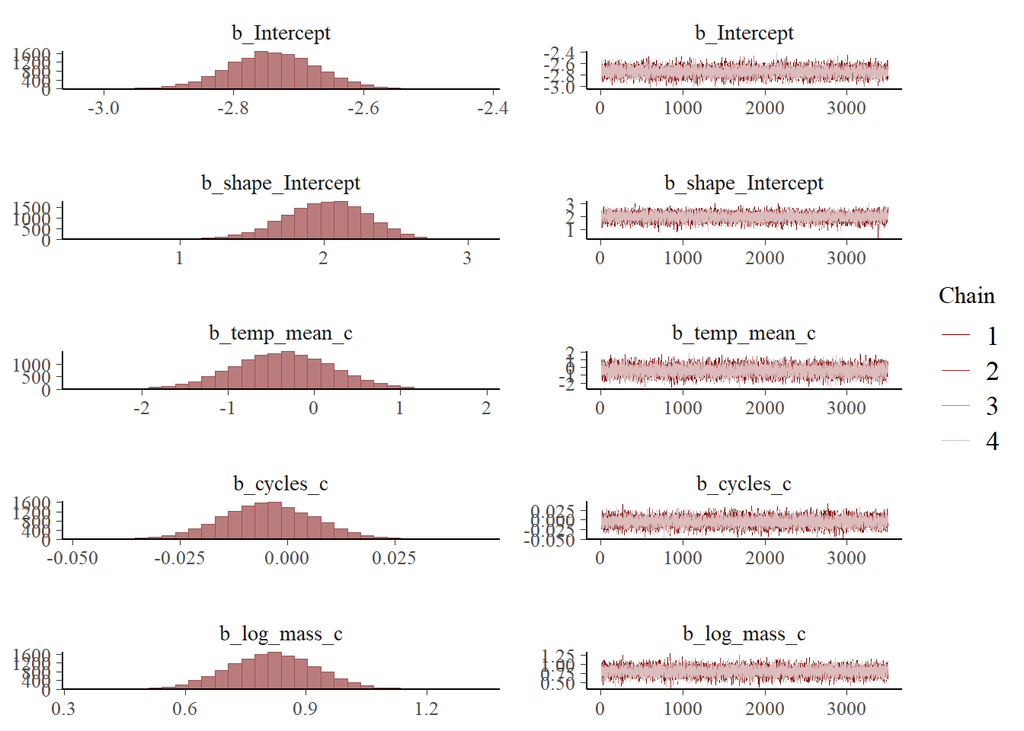

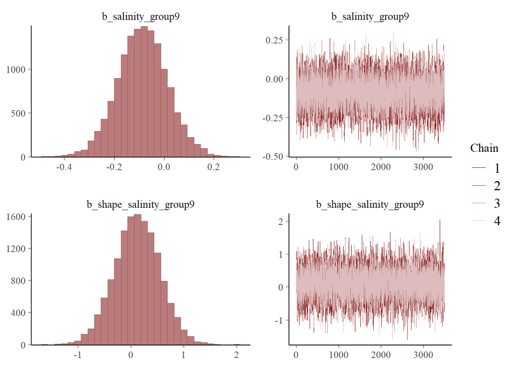

Using leave one out (loo) measure of fit, the model appears to preform well, two Pareto k estimates falls outside the good range (0.7, 1]

```
##
## Computed from 14000 by 58 log-likelihood matrix.
##
##          Estimate   SE
## elpd_loo    134.6 11.0
## p_loo        11.0  4.8
## looic      -269.2 22.0
## ------
## MCSE of elpd_loo is NA.
## MCSE and ESS estimates assume MCMC draws (r_eff in [0.8, 0.9]).
##
## Pareto k diagnostic values:
##                          Count Pct.    Min. ESS
## (-Inf, 0.7]   (good)     56    96.6%   4028
##    (0.7, 1]   (bad)       1     1.7%   <NA>
##    (1, Inf)   (very bad)  1     1.7%   <NA>
## See help('pareto-k-diagnostic') for details.
```

Model predictions generally align with the observed data, but there is a lot of uncertainty around this estimate.

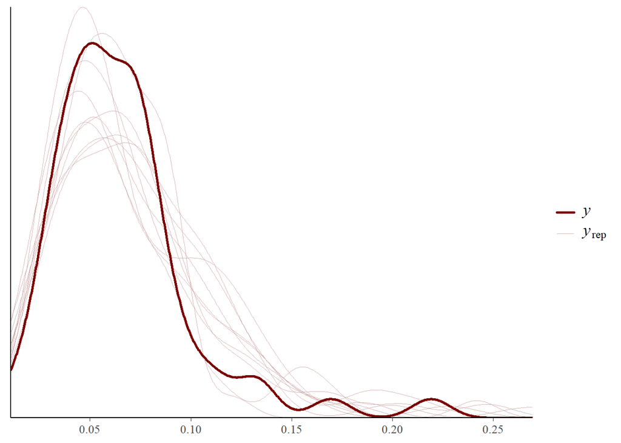

### 📈 Results

#### Table S2

**Table S2:** Fixed effect Estimates (β) and 95% Credible Intervals (95% CI) from a Bayesian Generalised Linear Mixed Model (GLMM) with a Gamma distribution and a log link

| Predictor | β | 95% CI |
| --- | --- | --- |
| Intercept | -2.740 | [-2.879, -2.603] |
| shape_Intercept | 2.010 | [1.428, 2.532] |
| temp_mean_c | -0.364 | [-1.51, 0.802] |
| cycles_c | -0.005 | [-0.026, 0.018] |
| log_mass_c | 0.816 | [0.597, 1.034] |
| salinity_group9 | -0.086 | [-0.283, 0.111] |
| shape_salinity_group9 | 0.117 | [-0.733, 0.945] |

Looking at the marginal mean difference between salinity groups

| salinity_group | emmean | lower.HPD | upper.HPD |
| --- | --- | --- | --- |
| 0 | 0.065 | 0.056 | 0.074 |
| 9 | 0.059 | 0.052 | 0.067 |

| contrast | estimate | lower.HPD | upper.HPD |
| --- | --- | --- | --- |
| salinity_group0 - salinity_group9 | 1.09 | 0.89 | 1.32 |

Here we we calculate the model-estimated marginal means for SMR for a unit increase in mass and transform this onto a fold-change scale. Where log(mass) has be centered, a vaule of 0 represents the mean mass of fish, and 1 corresponds to a fish with log(mass) = 1 unit above the mean (i.e. 2.7 times large).

| contrast | estimate | lower.HPD | upper.HPD |
| --- | --- | --- | --- |
| log_mass_c1 - log_mass_c0 | 2.26 | 1.84 | 2.84 |

Pulling the emmeans draws for our plot

#### Figure 1b

**NOTE: This plot is in the main text of the manuscript which is why it is Figure 1b (not Figure Si)**

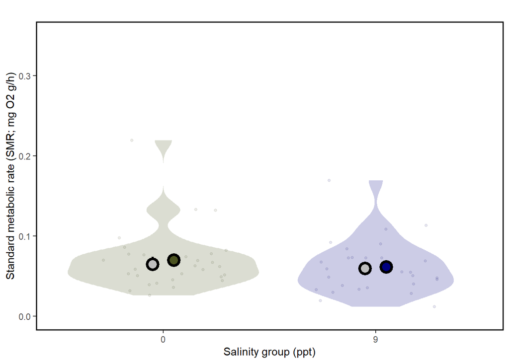

**Figure 1b:** The standard metabolic rate estimate (mg<sup>-1</sup> O<sub>2</sub> h<sup>-1</sup>) plotted by salinity treatment. The small transparent points are the observed values, the shaded area behind the points is the a kernel density of the observed data, the large coloured point (to the right) is the observed mean, the large grey point with error bars (to the left) is the model estimated marginal mean (eemean) 95% Credible Intervals (95% CI).

## Incremental regression analyses

Here we are following the methods Urbina et al. (2012)<sup>[1]</sup> with an incremental regression analyses, in order to determine the best fit for the MO<sub>2</sub> vs O<sub>2</sub> data

This analysis approach evaluates the relative ‘fit’ of each polynomial order equation starting at zero and increasing to the third order, permitting a mathematical assessment of whether fish were oxyconforming or oxyregulatoring. If the data is best fitted/predicted by a single linear relationship (1<sup>st</sup>-order polynomial) with a positive slope, this would suggests the fish were oxyconforming. Alternately, if the relationship is best modelled by a flat regression (0<sup>th</sup>-order polynomial), or a higher order polynomial (2<sup>nd</sup> or 3<sup>rd</sup>-order polynomial) the fish is likely oxyregulatoring.

### Building Bayesian regressions

Here we are using a Bayesian approach to model fitting with brm. These models take a long time to run, so I have saved them and re-loaded them to save time. I have also saved the summary data produced from the models, to save time, you can simply skip the hashed code and input the resulting summary data.

We will run our custom function, `bayes_incremental_regression_by_id`.

Let’s make define the output directory

⏭️ **Skip this step** if you have already run this once, or have downloaded the saved models or saved data files from GitHub (that’s why its hashed out). ⌛*This code takes a while to run* ⌛

During this part of the script I received an error, ‘Caused by error in `socketConnection()`:’. I think the system may be hitting a limit on the number of simultaneous socket connections. If you this part of the code and also get this issue, try reducing the number of parallel workers: plan(multisession, workers = 2), or run again after the error.

Load all models and store in a list, will use a lot of memory. You can also skip this step and load the resulting data frames below. I am using the custom function `load_rds`, so we can compare them and generate predictions.

⏭️ **Skip this step** if you have downloaded the saved data pulled from these models have also hased this out, bayes_reg_mods_fit.csv’ and ‘bayes_reg_mods_predictions.csv’. These are in the mod-data directory.

### Model fits

⏭️ **Skip this step** if you have downloaded **💿 bayes_reg_mods_fit.csv**.

It gets model fit parameters loo and r2 using the custom function, `incremental_regression_bayes_fits`. *⌛ This code takes a while to run ⌛*

Reading in this model fit data frame, in the case you did not load in all the models.

**Selecting the best fitting model**

elpd_loo, or the expected log pointwise predictive density for leave-one-out cross-validation, is a metric used in Bayesian model evaluation to assess the predictive accuracy of a model. The elpd_loo is an approximation of how well the model is expected to predict new data, based on leave-one-out cross-validation. Higher elpd_loo values indicate better predictive performance.

### Model predictions

⏭️ **Skip this step** if you have downloaded **💿 bayes_reg_mods_predictions.csv**.

It pulls our model predictions using a custom function `bayes_mod_predictions`.

Reading in the predicted data

We are going to combined this with our best fitting model df, so we know how they ranks for LOO.

### 📈 Results

#### Model selection summary

In most cases, the relationship between MO<sub>2</sub> and DO was best modelled with a 2<sup>nd</sup>-order polynomial (*n* = 22, 38% of fish), followed by a 3<sup>rd</sup>-order polynomial (*n* = 15, 26%), 1<sup>st</sup>-order polynomial (*n* = 11, 19%), and finally 0<sup>th</sup>-order polynomial (*n* = 10, 17%).

For the two most common models, 2<sup>nd</sup>- and 3<sup>rd</sup>-order polynomials, this could suggest the presence of a critical oxygen threshold (Pcrit) where the relationship between MO<sub>2</sub> and O<sub>2</sub> changes. To confirm the presence of a Pcrit, we need to validated the shape of the polynomials (see Pcrit model below). In any case, these type of models are indicative of **oxyregulator**.

| best_model_name | n | percent |
| --- | --- | --- |
| 0th-order polynomial | 10 | 17.24 |
| 1st-order polynomial | 11 | 18.97 |
| 2nd-order polynomial | 22 | 37.93 |
| 3rd-order polynomial | 15 | 25.86 |

Summary of fish best model with a linear function.

##### Mass effect

Checking if this pattern is driven by mass, as request by the reviewer.

| Best polynomial fit | Mean mass (g) | SD mass (g) | n |
| --- | --- | --- | --- |
| 0th-order polynomial | 0.56 | 0.32 | 10 |
| 1st-order polynomial | 0.50 | 0.23 | 11 |
| 2nd-order polynomial | 0.61 | 0.32 | 22 |
| 3rd-order polynomial | 0.47 | 0.13 | 15 |

Modling

###### Prior selection

These are the default priors for the model. We will use these.

| prior | class | coef | group | resp | dpar | nlpar | lb | ub | source |
| --- | --- | --- | --- | --- | --- | --- | --- | --- | --- |
|  | b |  |  |  |  |  |  |  | default |
|  | b | model_typelm_1 |  |  |  |  |  |  | default |
|  | b | model_typelm_2 |  |  |  |  |  |  | default |
|  | b | model_typelm_3 |  |  |  |  |  |  | default |
| student_t(3, 0.5, 2.5) | Intercept |  |  |  |  |  |  |  | default |
| student_t(3, 0, 2.5) | sigma |  |  |  |  |  | 0 |  | default |

###### Run model

Here we run the model, I have hashed this out because I have saved the model for quick reloading.

⏭️ **Skip this step** if you have downloaded the saved model ‘mass_mod.rds’

Here we reload the model

###### Model diagnostics

Checking model convergence

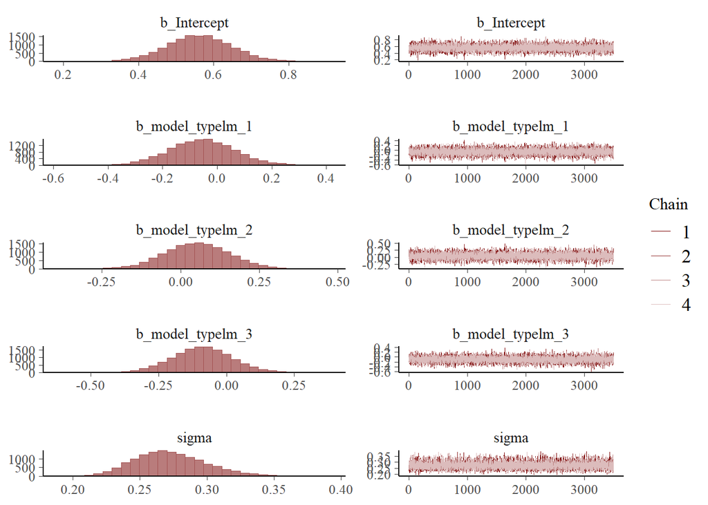

```
##
## Computed from 14000 by 58 log-likelihood matrix.
##
##          Estimate   SE
## elpd_loo    -10.2 10.3
## p_loo         6.8  2.8
## looic        20.5 20.6
## ------
## MCSE of elpd_loo is 0.1.
## MCSE and ESS estimates assume MCMC draws (r_eff in [0.8, 1.0]).
##
## All Pareto k estimates are good (k < 0.7).
## See help('pareto-k-diagnostic') for details.
```

Model predictions generally align with the observed data, but there is a lot of uncertainty around this estimate.

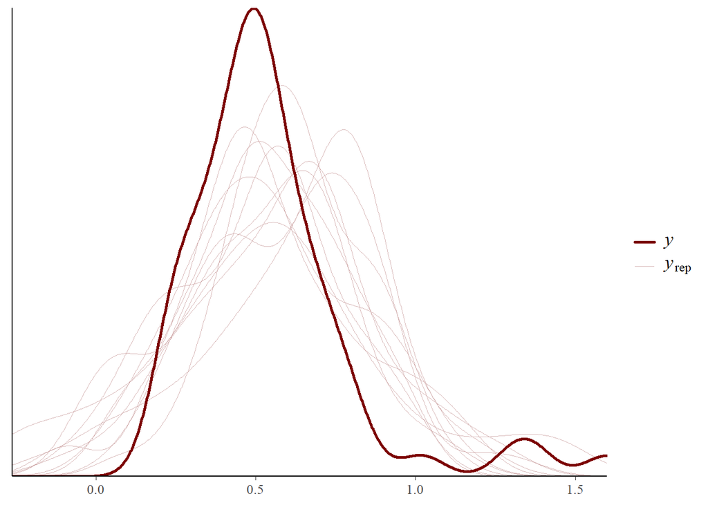

###### Results

| Predictor | β | 95% CI |
| --- | --- | --- |
| Intercept | 0.561 | [0.39, 0.729] |
| model_typelm_1 | -0.057 | [-0.294, 0.179] |
| model_typelm_2 | 0.051 | [-0.156, 0.256] |
| model_typelm_3 | -0.090 | [-0.314, 0.131] |

| model_type | emmean | lower.HPD | upper.HPD |
| --- | --- | --- | --- |
| lm_0 | 0.560 | 0.389 | 0.728 |
| lm_1 | 0.504 | 0.342 | 0.668 |
| lm_2 | 0.611 | 0.504 | 0.733 |
| lm_3 | 0.470 | 0.330 | 0.609 |

### Table S3

**Table S3:** Posterior mean differences in mass (g) (estimate) and 95% highest posterior density intervals (95% CrI) are shown for all pairwise comparisons among model types (0th- to 3rd-order polynomial). Estimates are derived from a Gaussian Bayesian model and represent differences in marginal posterior means on the response scale. A meaningful difference was inferred when the 95% CrI did not overlap zero.

| Contrast | Estimate (g) | 95% CrI |
| --- | --- | --- |
| 0th-order polynomial − 1st-order polynomial | 0.06 | -0.18 to 0.29 |
| 0th-order polynomial − 2nd-order polynomial | -0.05 | -0.26 to 0.15 |
| 0th-order polynomial − 3rd-order polynomial | 0.09 | -0.12 to 0.32 |
| 1st-order polynomial − 2nd-order polynomial | -0.11 | -0.3 to 0.1 |
| 1st-order polynomial − 3rd-order polynomial | 0.03 | -0.19 to 0.24 |
| 2nd-order polynomial − 3rd-order polynomial | 0.14 | -0.04 to 0.32 |

### Table S4

| Fish ID | r2 (CI) | Estimate (CI) | Percentage change | Evidence of oxyconforming |
| --- | --- | --- | --- | --- |
| d_9_25nov_3 | 0.197 (0.012 to 0.394) | 0.0011 ( 0.0003 to 0.0019) | 0.7437151 | Conforming |
| a_9_22nov_4 | 0.312 (0.094 to 0.491) | 0.0008 ( 0.0004 to 0.0013) | 0.5739880 | Conforming |
| b_9_22nov_1 | 0.231 (0.055 to 0.396) | 0.0005 ( 0.0002 to 0.0008) | 0.4310066 | Conforming |
| d_9_25nov_2 | 0.330 (0.102 to 0.507) | -0.0009 (-0.0013 to -0.0004) | -0.7599381 | Not conforming |
| a_0_25nov_1 | 0.137 (0.002 to 0.331) | -0.0004 (-0.0007 to 0.0000) | -0.2788575 | Not conforming |
| c_0_22nov_3 | 0.072 (0.000 to 0.256) | 0.0005 (-0.0005 to 0.0016) | 0.3013443 | Not conforming |
| a_0_24nov_3 | 0.058 (0.000 to 0.202) | 0.0005 (-0.0003 to 0.0012) | 0.2832654 | Not conforming |
| c_9_27nov_2 | 0.068 (0.000 to 0.255) | 0.0003 (-0.0003 to 0.0008) | 0.1697994 | Not conforming |
| a_9_22nov_1 | 0.084 (0.000 to 0.266) | 0.0003 (-0.0002 to 0.0008) | 0.2272965 | Not conforming |
| b_0_25nov_2 | 0.108 (0.001 to 0.290) | 0.0003 ( 0.0000 to 0.0006) | 0.2275231 | Not conforming |
| a_0_24nov_1 | 0.029 (0.000 to 0.134) | 0.0002 (-0.0005 to 0.0009) | 0.1072286 | Not conforming |

#### Ploting all models

Data set with all slopes and which model was best

Getting a plot for each best fit regression, and overlaying a global model for that model type.

Here we are grouping fish by best fitting model and getting an average trend. I have hashed the code so you don’t need to re-run the models

⏭️ **Skip this step** if you have downloaded the global models **‘.rds’** in the ‘bayes-regs-global’ folder

⏭️ **Skip this step** if you have downloaded the global_models_pred_df.csv

Load data frame

#### Figure S5

Best fit regressions with global models based on that polynomial order.

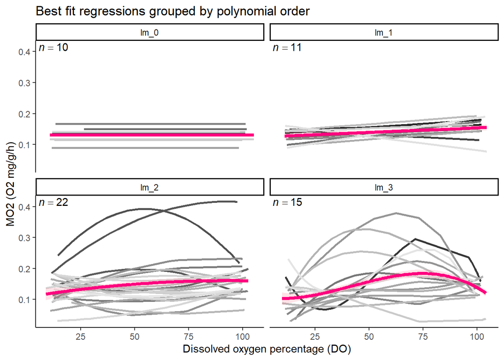

**Figure S5:** Individual regression curves showing the relationship between mass-specific oxygen consumption rate (ṀO₂; mg⁻¹ O₂ h⁻¹) and ambient dissolved oxygen (DO; % saturation), grouped by the best-fitting polynomial order (0ᵗʰ to 3ʳᵈ). Each panel represents fish whose ṀO₂–DO relationship was best modelled by that polynomial order, based on leave-one-out cross-validation (LOO-CV). Grey lines represent individual model fits; the bold pink line shows the group-level trend within each polynomial class. Fish were most commonly best fit by a 2ⁿᵈ-order polynomial (n = 22), followed by 3ʳᵈ-order (*n* = 15), 1ˢᵗ-order (*n* = 11), and 0ᵗʰ-order (**n = 10). Higher-order fits (2ⁿᵈ and 3ʳᵈ) and 0ᵗʰ-order fits are generally indicative of oxyregulating responses, while 1ˢᵗ-order fits may suggest oxyconforming behaviour when positively sloped.

## O₂crit model

We will calculate O₂crit using Chabot method and function `calcO2crit`.

This function uses the fifth percentile of the MO<sub>2</sub> values observed at dissolved oxygen levels ≥ 80% air saturation as the criterion to assess low MO<sub>2</sub> values. The algorithm then identifies all the MO<sub>2</sub> measurements greater than this minimally acceptable MO<sub>2</sub> value. Within this sub-set, it identifies the MO<sub>2</sub>2 measurement made at the lowest DO and thereafter considers this DO as candidate for breakpoint (named pivotDO in the script). A regression is then calculated using observations at DO levels < pivotDO, and a first estimate of O<sub>2crit</sub> is calculated as the intersection of this regression line with the horizontal line representing SMR. The script then goes through validation steps to ensure that the slope of the regression is not so low that the line, projected to normoxic DO levels, passes below any MO<sub>2</sub> values observed in normoxia. It also ensures that the intercept is not greater than zero. Corrective measures are taken if such problems are encountered.

lowestMO2 default is the `quantile(MO2[DO >= 80], p=0.05)`. It is used to segment the data and locate the pivotDO.

### Ploting O2crit

Here’s we are saving all O<sub>2crit</sub> models, even those MO<sub>2</sub>-O<sub>2</sub> relationships best modelled by 0<sup>th</sup>- and 1<sup>st</sup>-order polynomials.

Now printing the fish that were fitted with higher order-polynomials in the htlm document

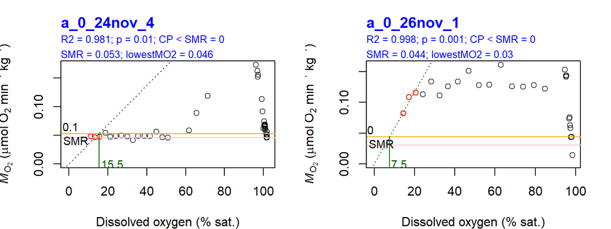

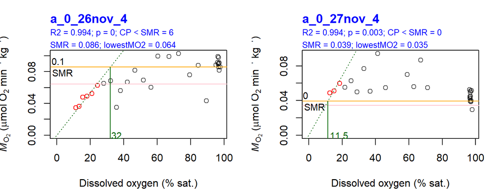

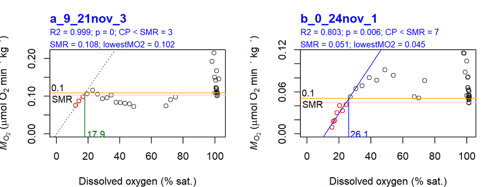

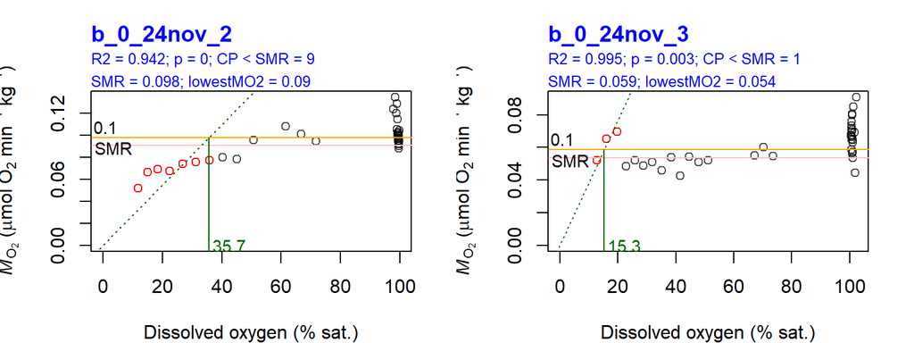

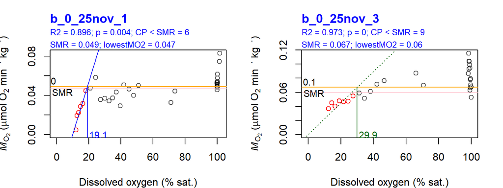

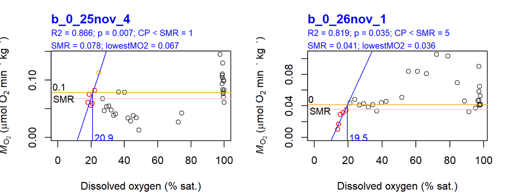